# Wharf to Wharf: 2018

Aaron Ferrucci

July 27, 2018

### Introduction

The Wharf to Wharf race happens every July in Santa Cruz. The mostly flat, 6-mile course hugs the coastline between Santa Cruz and Capitola. The race has grown in popularity since its beginning in 1973, with more than 13,000 registered participants in 2018.

Race results are available online. You can look up runners’ results by bib number, name, city and state. This is ok, but it’s not very handy for anyone wanting to do real data analysis.

I’ve written some code to scrape the data from the results page, clean it up, and plot some interesting things. The code is available on github; if you see a problem, fork my repo, fix it, and do a pull request!

```
## [1] "imputeAgeFromOldData(2018, 2015): found 24 age records to impute"
## [1] "imputeAgeFromOldData(2018, 2016): found 14 age records to impute"
## [1] "imputeAgeFromOldData(2017, 2015): found 20 age records to impute"
## [1] "imputeAgeFromOldData(2017, 2016): found 11 age records to impute"
## [1] "imputeAgeFromOldData(2018, 2017): found 8 age records to impute"
```

### Basic Info

Histogram of runner ages:

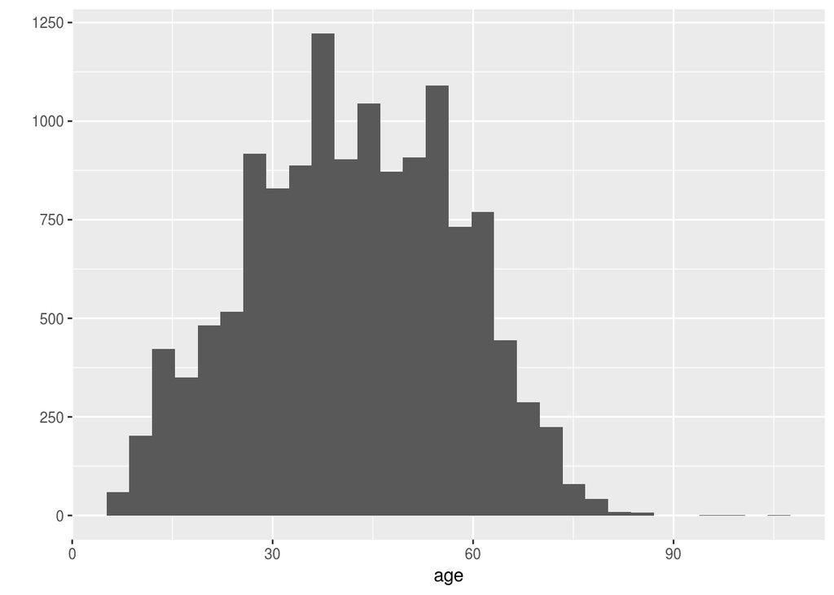

Histogram of genders:

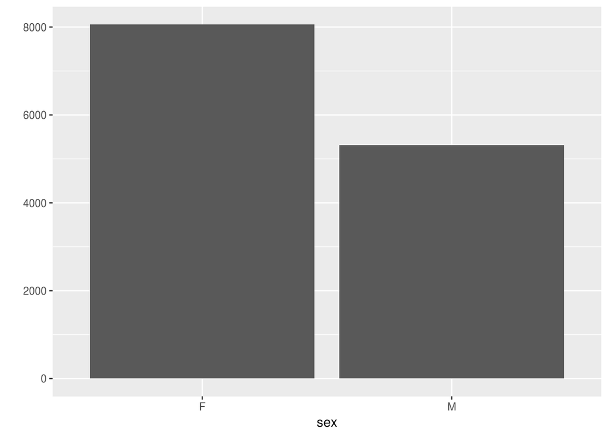

Country of origin. In 2018, we have the USA, Australia and Kenya:

```
##
##    AU   KEN   USA
##     2     7 13367
```

#### Charts

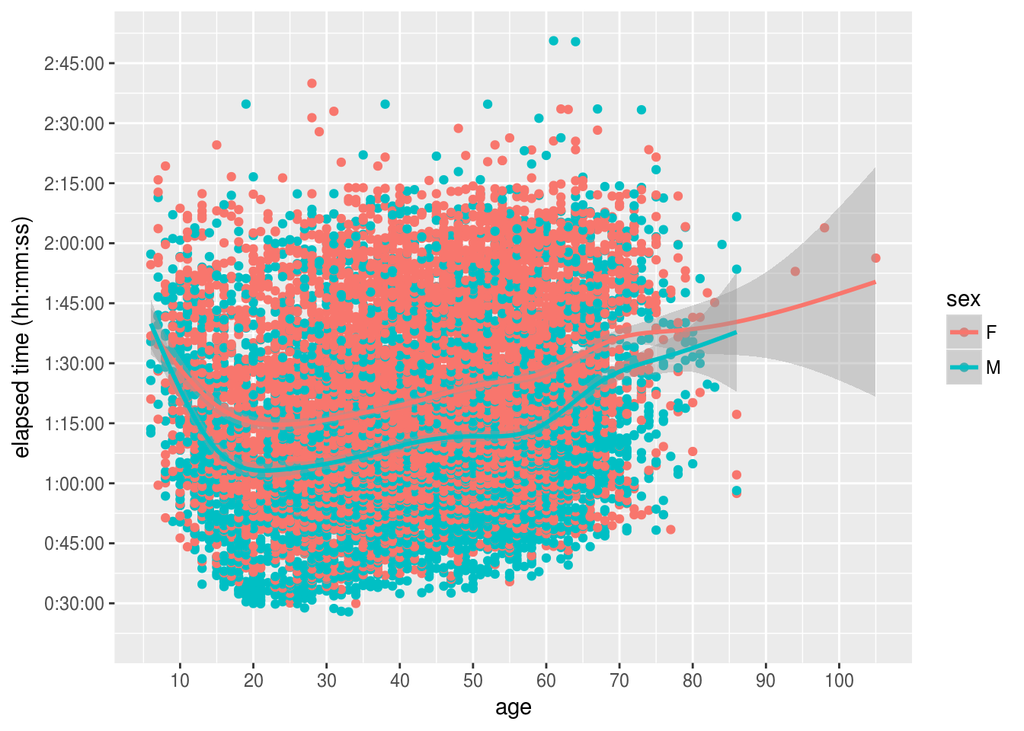

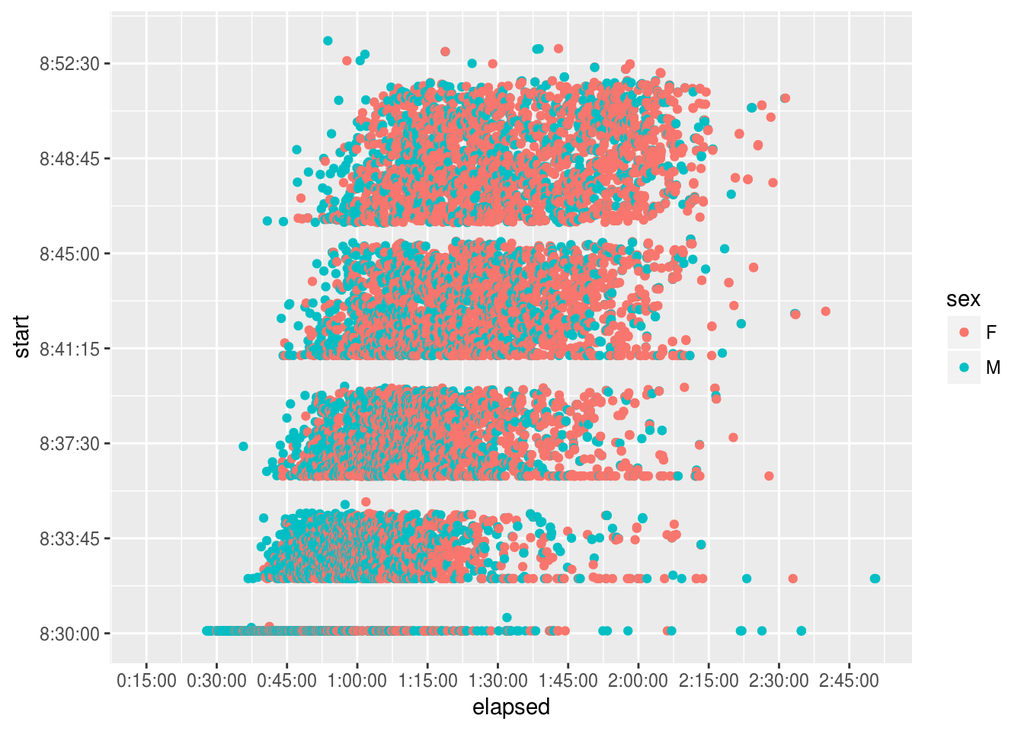

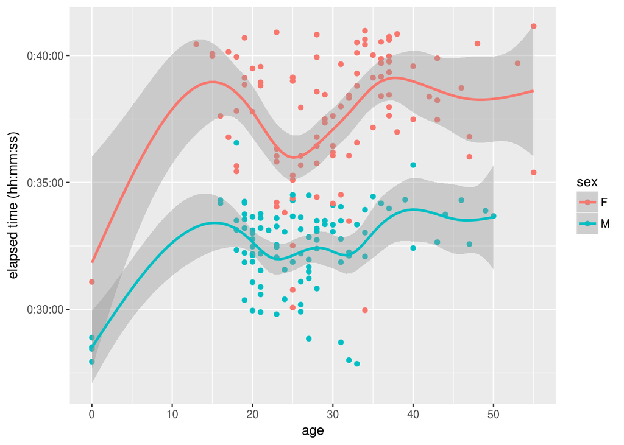

#### References

Github link: https://github.com/aaronferrucci/wharf2wharf  
Wharf to Wharf main page: http://www.wharftowharf.com/  
Wharf to Wharf results page: http://www.wharftowharf.com/results  
Definition of jogging: https://en.wikipedia.org/wiki/Jogging